# Assigment 1 Reproducible Research - abigail2105

## Are there differences in activity patterns between weekdays and weekends?

To carry out this analysis, it is necessary to work out the days of the week for the data set. This was done using the following code.

```r
actdates <- activity[,2] # extract the dates
actdates <- as.Date(actdates, format="%Y-%m-%d") # convert from factor to date format
wdays <- weekdays(actdates) # change to days of the week
wdays <- gsub("Minggu", "weekend", wdays) # Sunday in Indonesian"
wdays <- gsub("Sabtu", "weekend", wdays) # Saturday in Indonesian
wdays <- gsub("Senin", "weekday", wdays) # Monday in Indonesian
wdays <- gsub("Selasa", "weekday", wdays) # Tuesday in Indonesian
wdays <- gsub("Rabu", "weekday", wdays) # Wednesday in Indonesian
wdays <- gsub("Kamis", "weekday", wdays) # Thursday in Indonesian
wdays <- gsub("Jumat", "weekday", wdays) # Friday in Indonesian
table(wdays) # verify wdays now converted to weekend and weekdays
```

```
## wdays
## weekday weekend
##   12960    4608
```

```r
actdat <- cbind(act,wdays) # bind to the data frame with the in-filled data set
```

With this data frame, it is now possible to compare the average steps taken by 5 minute time interval over 24 hours between weekdays and weekends. This was done using the following code

```r
wkdat <- actdat[actdat$wdays == "weekday",] # weekday data
wedat <- actdat[actdat$wdays == "weekend",] #weekend data
wkdat <- wkdat[,c(1,4)] # select infilled steps and interval
wedat <- wedat[,c(1,4)]  # select infilled steps and interval
summary(wkdat)
```

```
##     newsteps         interval
##  Min.   :  0.00   Min.   :   0.0
##  1st Qu.:  0.00   1st Qu.: 588.8
##  Median :  0.00   Median :1177.5
##  Mean   : 35.61   Mean   :1177.5
##  3rd Qu.: 24.00   3rd Qu.:1766.2
##  Max.   :806.00   Max.   :2355.0
```

```r
summary(wedat)
```

```
##     newsteps         interval
##  Min.   :  0.00   Min.   :   0.0
##  1st Qu.:  0.00   1st Qu.: 588.8
##  Median :  0.00   Median :1177.5
##  Mean   : 42.36   Mean   :1177.5
##  3rd Qu.: 35.00   3rd Qu.:1766.2
##  Max.   :785.00   Max.   :2355.0
```

```r
ints <- levels(as.factor(activity$interval)) # vector of intervals
ints <- as.integer(ints) # convert to integer
x <- c(1:length(ints)) # counts for functions
fun5 <- function (x) {
      stps <- wkdat[wkdat[,2] == ints[x],1]
      val <- mean(stps)
}
wksteps <- sapply(x, fun5) # produces average steps/interval for weekdays
fun6 <- function (x) {
      stps <- wedat[wedat[,2] == ints[x],1]
      val <- mean(stps)
}
westeps <- sapply(x, fun6)

# to determine average maximum activity period of 5 minutes
totact <- wksteps+westeps
maxact <- max(totact)
tot <- cbind(totact,ints)
maxtot <- tot[totact == maxact,]
maxStepTime <- maxtot[2]
maxStepTime
```

```
## ints
##  835
```

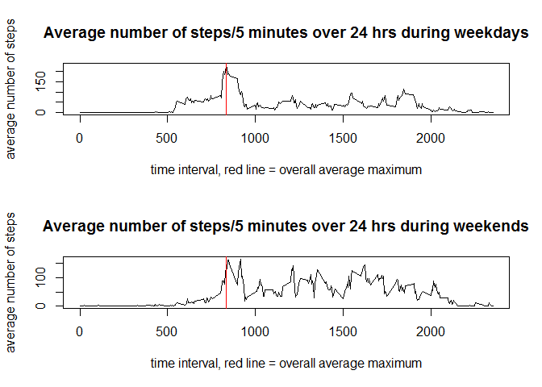

```r
par(mfcol = c(2,1))

plot(ints,wksteps, type = "l", main = "Average number of steps/5 minutes over 24 hrs during weekdays", xlab = "time interval, red line = overall average maximum", ylab = "average number of steps")
abline(v = maxStepTime, col = 2)

plot(ints,westeps, type = "l", main = "Average number of steps/5 minutes over 24 hrs during weekends", xlab = "time interval, red line = overall average maximum", ylab = "average number of steps")
abline(v = maxStepTime, col = 2)
```

The peak in average activity for all days combined was during the time interval given by masStepTime, which was 835

Comparing the plots of weekday and weekend activity, it seems that the subject was more active early in the morining on weekdays, and more active in the middle of the day and in the evenings at weekends.

The peak in walking activity is around mid-morning on both weekdays and weekends. Total steps taken and average steps per 5 minutes tend to be higher at weekends. However the highest peak activity occurred during a weekday.

## Conclusion:

Overall, the data show that activity (steps) varies considerably between days and time of day, however the average number of steps taken per day is around 10,766, and the average steps per 5 minutes is around 37. Confidence intervals could be calculated for steps per day using a normal approximation, as the distribution is approximately normal and the sample size (61 days) is over 30.

Average figures are similar using the two methods for addressing missing data (remove NA records or use average per 5 minute interval). However the latter method gives a smaller spread (sharper peak).

The data also show that on average more steps per day are taken at weekend. Weekend activity tends to begin later, be more spread out during the day and continue until later at night.